# 8. Introduction to functions

31st March 2015

Goals:

- Learn why functions are a helpful programming tool
- Relate functions in programming to something we already know
- See examples of simple Python functions
- Homework: Research + programming

## Previously seen on "Python Cognovo classes"

- In one of the homeworks (lecture 4: Memory refresher, exercises) we have cleaned up a sentence:

```python
sentence = 'today is a  very nice day,but  we have to spend it in the lab.too   bad,no?'
```

- Clean up: remove redundant spaces, capitalize the letters at the beginning of a sentence and after a punctuation sign
- This kind of job is very common in programming (e.g. filling out online forms)
- Let's consider a simpler version of this task: cleaning up a name user entered

## The task

- We are organising a party and asking everyone to enter their name in an online form we have created
- A person enters their name, and we print a personalized welcome message

```python
# these lines display the form below, just to give you an idea of a "real" scenario of the task
from IPython.display import HTML

input_form = """
<div style="background-color:gainsboro; border:solid black; width:300px; padding:20px;">
Your name: <input type="text" id="var_name" value="Ivana"><br>
</div>
"""

HTML(input_form)
```

Your name:

## The task

- We can assume that in most of the cases users will do what they are asked, but typos and mistakes still happen so we might see:

  `_ivana` (space in front of the name)

  `ivana_` (space after the name)

  `IVAna` (mixed lowercase and uppercase letters)
- Our task is to make sure that even when a user has typed a name with such mistakes, we still print a nice looking message:

  `Hello Ivana`

## Let us (you ;) write a program which does that!

## One possible solution...

```python
name = raw_input('What is your name? ')

clean_name = name.strip()
clean_name = clean_name.lower()
clean_name = clean_name.capitalize()

print 'Hello', clean_name
```

```
What is your name? ivaNA
Hello Ivana
```

### Now imagine that you also ask them for their surname

```python
# you can again ignore these lines, they just plot the form below
from IPython.display import HTML

input_form = """
<div style="background-color:gainsboro; border:solid black; width:300px; padding:20px;">
Your name: <input type="text" id="var_name" value="Ivana"><br>
Surname: <input type="text" id="var_name" value="Kajić"><br>
</div>
"""

HTML(input_form)
```

Your name:  
Surname:

```python
name = raw_input('What is your name? ')

clean_name = name.strip()
clean_name = clean_name.lower()
clean_name = clean_name.capitalize()

print 'Hello', clean_name

surname = raw_input('What is your surname? ')
clean_surname = surname.strip()
clean_surname = clean_surname.lower()
clean_surname = clean_surname.capitalize()

print 'Hello', clean_surname
```

```
What is your name? IVANA
Hello Ivana
What is your surname? kajic
Hello Kajic
```

### And now imagine we ask for their mother's and father's name...

- Again copy-paste? :(

## No! We have functions to help us! :)

- But first, let's take a break!

## Describe the image (à la Topics & Concerns)

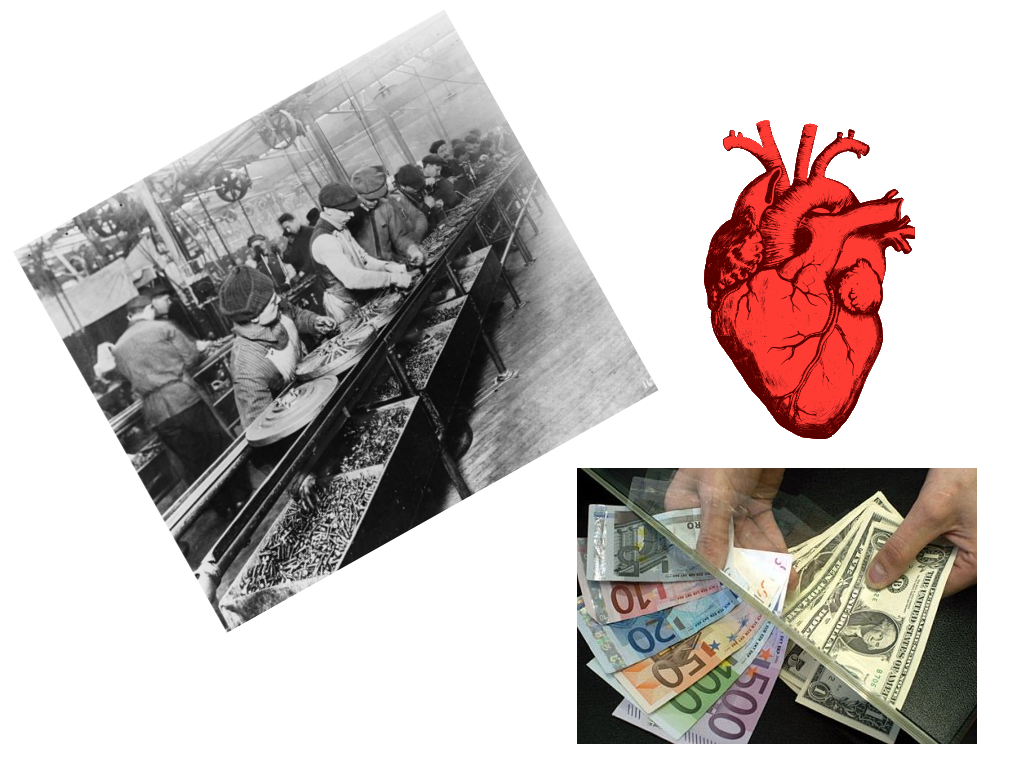

```python
from IPython.display import Image

Image(filename='./img/functions.png', retina=True)
```

## Cleaning up a name using a function

```python
def clean_up(text):
    clean_text = text.strip()
    clean_text = clean_text.lower()
    clean_text = clean_text.capitalize()

    return clean_text
```

```python
name = raw_input('What is your name?' )
surname = raw_input('What is your surname?' )
mothers_name = raw_input("What is your mother's name? ")
```

```python
clean_name = clean_up(name)
clean_surname = clean_up(surname)
clean_mothers_name = clean_up(mothers_name)
```

```python
print 'Hello,', clean_name, '(', clean_mothers_name, ')', clean_surname
```

```
Hello, Ivana ( Monika ) Kajic
```

## Python functions

```python
def convert_euro_to_kuna(amount_euro):
    """
    Converts an amount in Euro (EUR) to Croatian kuna (HRK).
    Parameters:
        amount_euro: Amount of money in Euro
    Returns:
        amout_kuna: Amount of money in Kuna
    """
    amount_kuna = 0
    if amount_euro > 0:
        amount_kuna = amount_euro*7.65
    else:
        print 'Hey, I can only convert money if you have it!'

    return amount_kuna

money_ivana_takes_to_croatia = convert_euro_to_kuna(100)
```

## An example

```python
def square(x):
    return x**2

print square(3)
```

```
9
```

```python
# what does this excerpt do?

for i in range(4):
    print i, '->', square(i)
```

## Terminology to remember

- Definition of a function vs. call of a function
- Parameters and arguments
- Return values
- Docstring (inspect them with ? character in IPython)

## Research homework

- How are functions defined and called in Matlab and R?
- How are parameters defined, and how are arguments passed?
- How do you return a value?

## Programming homework

1. Create a file text_functions.py and write following functions inside:

   ```
   * `count_vowels`: returns the number of vowels in a given word, otherwise -1

   * `remove_vowels`: returns a word with all the vowels removed AND the number of letters in a new word
   ```

2. Now, create a new file called text.py in the same directory, containing the following lines:

```python
from text_functions import count_vowels, remove_vowels

sentence = 'Is it possible to understand this sentence even if the vowels are missing?'

nr_vowels = count_vowels(sentence)
print 'This sentence has:', nr_vowels, ' vowels'

new_sentence, length = remove_vowels(sentence)
print 'If we remove them, we are still left with ', length, ' letters'
print new_sentence
```

- Analyse this program and explain it line by line by writing comments in the code